# A3: SPL Library Checkouts

Emily Hao

### Introduction

Using this dataset of all items checked out from the Seattle Public Library in 2022-2023, I plan to more specifically analyze Charles Dickens’ books. I remember reading quite a few of his books as part of my high school’s literature curriculum, so I was curious to see how popular his books were in relation to one another by analyzing how many of his books were checked out from the Seattle Public Library. I was also curious to see if people still consistently read his books, even though they are classified more as timeless literature classics and books that aren’t “trendy” or current “pop culture”. I plan to compare data between physical and digital checkouts for his books, and by doing so, I hope to draw insight on current reading trends. I will also look at Charles’ Dickens top books by total checkouts in order to see what his most popular and least popular books are, and how those trends changed or did not change between 2022 and 2023.

### Summary Information

First, when filtering the entire 2022-23 dataset, I found that out of the 9196991 total checkouts from the Seattle Public Library, 4010 were of Charles Dickens’ books. This makes the proportion of the total Charles’ Dickens checkouts to the total amount of checkouts 4.36^{-4}.

During the entire 2022 to 2023 time period, the Charles Dickens physical book with the most checkouts is *A Christmas Carol*, with 107 checkouts. The Charles Dickens digital book with the most checkouts is *A Tale of Two Cities*, with 820 checkouts.

### The Dataset

- Who collected/published the data?
  - The Seattle Public Library provided this data as an open source dataset.
- What are the parameters of the data (dates, number of checkouts, kinds of books, etc.)?
  - This data is collected between January 2022 and January 2023, categorizing books as either physical and digital and by their material type, including ebooks, audiobooks, print, or sound discs. In my specialized Charles Dickens dataset, some of the book labels include “Young Adult,” “Classic Literature,” “Fiction,” and “Literature.” The number of checkouts in this dataset is recorded monthly for each book title found at the Seattle Public Library.
- How many observations (rows) are in your data?
  - There are 2,757,014 rows in the original SPL dataset, but there are 1,190 rows in the filtered Dickens dataset.
- How many features (columns) are in the data?
  - There are 12 columns in the data.
- How was the data collected or generated?
  - This data was collected on a monthly basis, counting the Seattle Public Library checkouts by each book title for all physical and electronic items.
- Why was the data collected?
  - This data was collected in order to record the checkouts of physical and digital library items. the different reading trends over time, such as how print and electronic items have changed or which authors/books became popular during certain periods of times.
- What, if any, ethical questions do you need to consider when working with this data?
  - One ethical question that may need to be considered when working with this dataset is possibly concerns over privacy. Some people may feel that the Seattle Public Library is intruding upon their privacy because their book checkout data, though essentially anonymous, is being collected, uploaded, and then shared publicly on the internet.
- What are possible limitations or problems with this data? (at least 200 words)
  - Some possible problems with this data are the inconsistencies in certain columns, specifically Creator and Title. Author names may either be formatted as “last name, first name”, or “first name last name.” Book titles also vary depending on a multitude of factors, including if they’re lowercased, abridged, or from different publishers, etc. Some works don’t have an author’s name included in the Creator’s section, or some works may have multiple ISBN numbers. These inconsistencies can make analyzing the dataset more difficult, leaving more opportunities for variation and inaccuracies in the data analysis. Another main problem of this dataset is its timeframe of only one year. Trends would become more apparent and clear if analyzed from a longer timeframe, such as over several years. For example, it would be much more meaningful to draw an analysis of material type checkout trends over the course of several years than just one. Finally, I think this dataset could be even more compelling if it included the timeframe of each checkout item, such as how many days each book was checked out for. This might help provide more insight into the average amount of time people generally spend on a book, or if there’s a correlation between time checked out on a book and the book’s material type.

### First Trends Over Time Chart

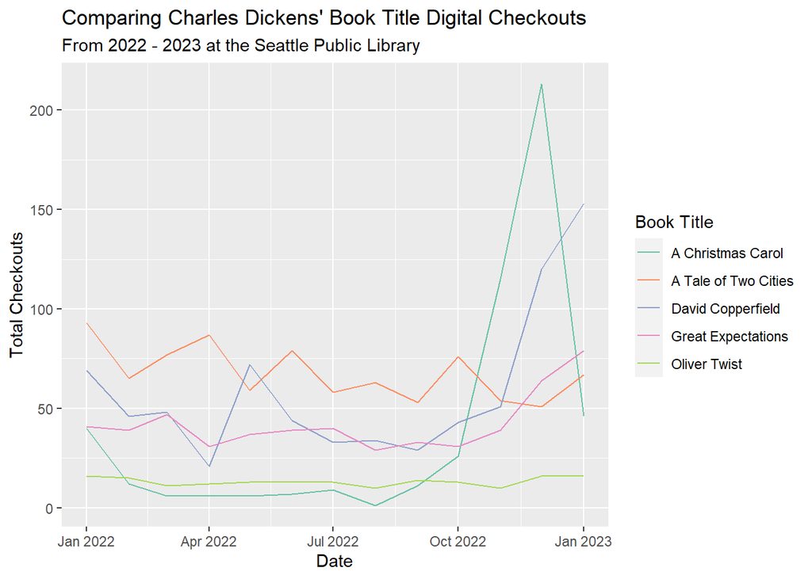

### Second Trends Over Time Chart

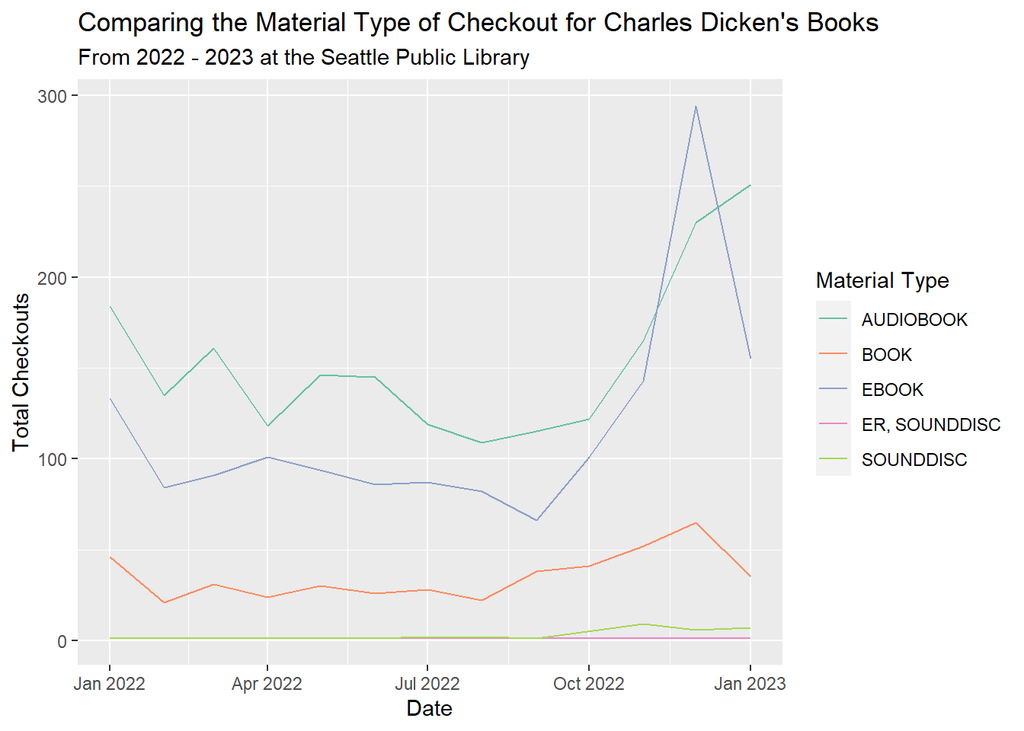

This chart compares the material type of the Seattle Public Library’s checkouts for Charles Dickens’ books. I included this chart because I was interested to analyze how material types for books would change or not change over time, especially as technology has become more integrated in our lives. I was also wondering what material type users generally prefer to read, and whether or not this preference would change. A pattern I noticed is how each of the material type categories seem to have declined in total checkouts from January 2022 up until around October 2022 before increasing again. In the case of audiobooks and ebooks, which have been the main preference of material types for users, their total checkouts increased greatly around December and January, with ebooks spiking up to almost 300 total checkouts. The spikes in total checkouts for audiobooks, ebooks, and print books around this time could be attributed to the holidays and New Year’s resolutions of reading more. In general, people generally prefer digital material types over reading a physical copy by a large margin, and not many people prefer sound discs. I thought this was surprising since I knew that audiobooks and ebooks were popular, but I didn’t think their total checkouts would be significantly more than print books.

### Your Choice

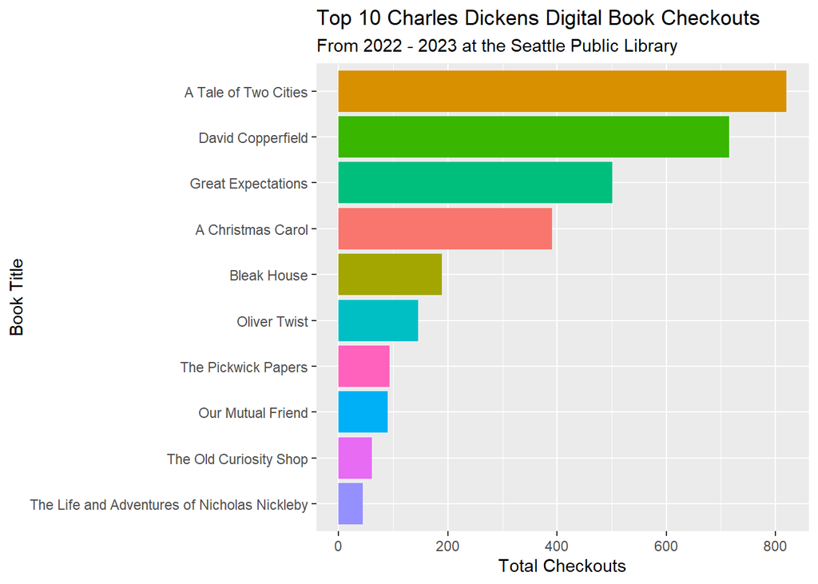

This bar chart compares Charles Dickens’ top 10 books, based on digital checkouts at the Seattle Public Library. I thought it would be interesting to compare these factors to see which of his works are the most popular, and how much more or less popular they are in relation to one another. Based on my previous knowledge of Charles Dickens, I knew that *A Tale of Two Cities* (820 checkouts) would be his most popular book, but looking at this data visualization, *David Copperfield* (715 checkouts) is also an extremely popular book. By a large margin, both *A Tale of Two Cities* and *David Copperfield* are by far his two most popular books. After *Oliver Twist*, the rest of his books only have less than a hundred checkouts in the entire 2022 to 2023 year. I thought it was interesting to see how the most popular book, *A Tale of Two Cities*, had more than 776 checkouts than the 10th most popular book, *The Life and Adventures of icholas Nickleby*. I would be curious to see, over a longer period of analysis, if there this ranking was static or changed over time.